# 課題10 解答：BG/NBDによる顧客ベース分析とCLV試算

計量経済学II

作者

Kei Ikegami

**ノートこの解答について**

各問の完全な実行可能コードと、「なぜこう書くか」「どこで間違えやすいか」の解説を付す。部分点基準は各問の末尾に記載する。

# Part 1：ネットスーパーの顧客ベースを自作する

## 問1：購買イベントをシミュレーションする

```r
N <- 2000
T_cal <- 52
T_holdout <- 26
T_total <- T_cal + T_holdout

r_true <- 0.9; alpha_true <- 7.0; a_true <- 0.9; b_true <- 3.2

lambda_true <- rgamma(N, shape = r_true, rate = alpha_true)
p_true      <- rbeta(N, a_true, b_true)

cat("E[lambda] =", r_true / alpha_true, "(週あたり平均購買率)\n")
```

```
E[lambda] = 0.1285714 (週あたり平均購買率)
```

```r
cat("E[p] =", a_true / (a_true + b_true), "(平均離脱確率)\n")
```

```
E[p] = 0.2195122 (平均離脱確率)
```

```r
simulate_full_history <- function(lambda, p_drop, T) {
  t <- 0
  events <- c()
  repeat {
    wait <- rexp(1, rate = lambda)
    t_next <- t + wait
    if (t_next > T) break
    t <- t_next
    events <- c(events, t)
    if (runif(1) < p_drop) break
  }
  events
}

all_events <- vector("list", N)
for (i in 1:N) {
  all_events[[i]] <- simulate_full_history(lambda_true[i], p_true[i], T_total)
}

cat("\n全顧客の平均購買回数(78週合計):", mean(sapply(all_events, length)), "\n")
```

```
全顧客の平均購買回数(78週合計): 4.0595
```

**解説**：`rgamma(shape = r, rate = alpha)`のパラメータの与え方に注意する。Rの`rgamma()`は`rate`（尺度パラメータの逆数）で指定するのがデフォルトであり、講義ノートの記法 $\lambda \sim \text{Gamma}(r, \alpha)$（$\alpha$が尺度パラメータの逆数）とちょうど対応している。`shape`と`scale`を取り違えると、まったく違うスケールの$\lambda$が生成されてしまうので要注意。

`simulate_full_history()`の`repeat`ループは、「次の購買までの待ち時間を引く→観測期間を超えたら終了→イベントを記録→確率$p$で離脱判定」という手順を素直にコードにしたものである。このループの書き方自体は、講義ノートのRシミュ1・Rシミュ2と全く同じ構造である。

**部分点基準**：`rgamma`・`rbeta`のパラメータの与え方が正しいこと（5点）、`simulate_full_history`の待ち時間・離脱判定のロジックが正しいこと（5点）。`shape`と`rate`を逆にした場合、DGP自体はエラーなく動くが、後続の全ての推定・検証がおかしくなるので、E[lambda]・E[p]の検算を必ず行うこと。

## 問2：calibration期間のRFM要約統計量を作る

```r
x_cal  <- sapply(all_events, function(ev) sum(ev <= T_cal))
tx_cal <- sapply(all_events, function(ev) {
  ev_cal <- ev[ev <= T_cal]
  if (length(ev_cal) == 0) 0 else max(ev_cal)
})

cat("x_calの要約:\n")
```

```
x_calの要約:
```

```r
summary(x_cal)
```

```
   Min. 1st Qu.  Median    Mean 3rd Qu.    Max.
   0.00    1.00    2.00    3.23    4.00   39.00
```

```r
cat("\ntx_calの要約(x>0の顧客のみ):\n")
```

```
tx_calの要約(x>0の顧客のみ):
```

```r
summary(tx_cal[x_cal > 0])
```

```
     Min.   1st Qu.    Median      Mean   3rd Qu.      Max.
 0.008349 10.166093 26.008752 26.396934 43.312303 51.999924
```

**解説**：ここが「holdoutの情報を使わない」という制約の実装ポイントである。`all_events`には78週分の全イベントが入っているが、`x_cal`・`tx_cal`の計算では`ev <= T_cal`で明示的に52週以内に絞り込む。この絞り込みを忘れると、calibration期間の推定にholdout期間の情報が漏れ込み（data leakage）、holdout検証の意味がなくなってしまう——これは今回の課題全体で最も重要な「やってはいけないこと」の1つである。

**部分点基準**：`x_cal`・`tx_cal`の両方が正しく52週以内に限定されていること（10点）。片方でもholdout情報が混入していたら大幅減点。

## 問3：可視化と記述統計

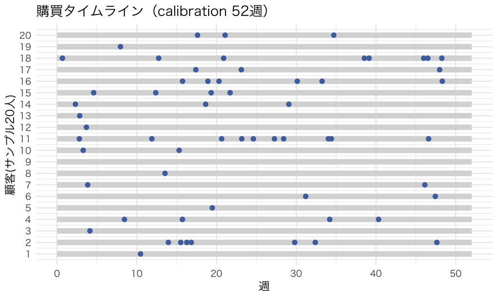

20人分の購買タイムライン（calibration 52週）

```r
sample_ids <- sample(1:N, 20)
timeline_list <- lapply(seq_along(sample_ids), function(k) {
  ev <- all_events[[sample_ids[k]]]
  ev_cal <- ev[ev <= T_cal]
  # 購買0回の顧客は rep(k, 0) が長さ0になり、0行のdata.frameになる（安全）
  # y軸はサンプル内の通し番号k（数値）にする（factorにするとannotateの数値yと衝突する）
  data.frame(customer = rep(k, length(ev_cal)), event_time = ev_cal)
})
timeline_df <- do.call(rbind, timeline_list)

ggplot(timeline_df, aes(x = event_time, y = customer)) +
  annotate("segment", x = 0, xend = T_cal, y = 1:20, yend = 1:20,
           color = "gray85", linewidth = 3) +
  geom_point(color = "#4C72B0", size = 2.2) +
  labs(x = "週", y = "顧客(サンプル20人)", title = "購買タイムライン（calibration 52週）") +
  scale_y_continuous(breaks = 1:20)
```

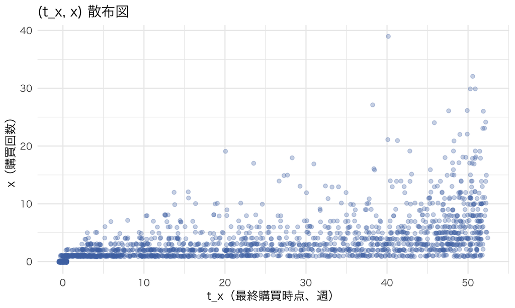

全顧客の (t_x, x) 散布図

```r
scatter_df <- data.frame(x = x_cal, tx = tx_cal)
ggplot(scatter_df, aes(x = tx, y = x)) +
  geom_jitter(alpha = 0.3, width = 0.5, height = 0.15, color = "#4C72B0") +
  labs(x = "t_x（最終購買時点、週）", y = "x（購買回数）", title = "(t_x, x) 散布図")
```

```r
cat("x=0の顧客割合:", round(mean(x_cal == 0), 3), "\n")
```

```
x=0の顧客割合: 0.146
```

```r
cat("xの平均:", round(mean(x_cal), 3), "  最大値:", max(x_cal), "\n")
```

```
xの平均: 3.23   最大値: 39
```

```r
cat("calibration期間の総購買回数:", sum(x_cal), "\n")
```

```
calibration期間の総購買回数: 6460
```

**部分点基準**：図が2つとも意図した形式で描けていること（各3点、計6点）、記述統計が正しく計算されていること（4点）。

# Part 2：推定・P(alive)・holdout検証・CLV

## 問4：BG/NBD対数尤度の実装とMLE

```r
logsumexp2 <- function(log_a, log_b) {
  m <- pmax(log_a, log_b)
  m + log(exp(log_a - m) + exp(log_b - m))
}

bgnbd_loglik <- function(r, alpha, a, b, x, tx, T) {
  ln_Bab <- lbeta(a, b)

  ln_A0 <- lbeta(a, b + x) - ln_Bab +
    lgamma(r + x) - lgamma(r) +
    r * log(alpha) - (r + x) * log(alpha + T)

  ln_A1 <- ifelse(
    x > 0,
    lbeta(a + 1, b + x - 1) - ln_Bab +
      lgamma(r + x) - lgamma(r) +
      r * log(alpha) - (r + x) * log(alpha + tx),
    -Inf
  )

  logsumexp2(ln_A0, ln_A1)
}

neg_loglik_bgnbd <- function(theta_log, x, tx, T) {
  params <- exp(theta_log)
  r <- params[1]; alpha <- params[2]; a <- params[3]; b <- params[4]
  -sum(bgnbd_loglik(r, alpha, a, b, x, tx, T))
}

theta_init <- log(c(r = 1, alpha = 1, a = 1, b = 1))

opt_result <- optim(
  par = theta_init, fn = neg_loglik_bgnbd,
  x = x_cal, tx = tx_cal, T = rep(T_cal, N),
  method = "L-BFGS-B", hessian = TRUE
)

theta_hat <- exp(opt_result$par)
names(theta_hat) <- c("r", "alpha", "a", "b")

true_params <- c(r = r_true, alpha = alpha_true, a = a_true, b = b_true)

vcov_log <- solve(opt_result$hessian)
se_log <- sqrt(diag(vcov_log))
se_orig <- theta_hat * se_log   # delta法

inference_df <- data.frame(
  parameter = names(true_params),
  true_value = true_params,
  estimate = round(theta_hat, 4),
  se = round(se_orig, 4),
  ci_lower = round(theta_hat - 1.96 * se_orig, 4),
  ci_upper = round(theta_hat + 1.96 * se_orig, 4)
)
kable(inference_df, caption = "真値・推定値・SE・95%信頼区間")
```

真値・推定値・SE・95%信頼区間

|  | parameter | true_value | estimate | se | ci_lower | ci_upper |
| --- | --- | --- | --- | --- | --- | --- |
| r | r | 0.9 | 0.9189 | 0.0397 | 0.8411 | 0.9966 |
| alpha | alpha | 7.0 | 7.2940 | 0.4224 | 6.4662 | 8.1219 |
| a | a | 0.9 | 0.9254 | 0.1198 | 0.6905 | 1.1603 |
| b | b | 3.2 | 3.2118 | 0.5393 | 2.1547 | 4.2689 |

**解説**：この課題の中で最も間違えやすい問題である。特に注意すべき点は次の3つ。

1. **`ifelse(x > 0, A, -Inf)`のAの部分は、$x=0$の行についても評価される**。Rの`ifelse()`は3つの引数（条件、真の場合の値、偽の場合の値）を全て計算してから条件で選択する仕組みなので、`x=0`の行では`b + x - 1 = b - 1`となり、`lbeta(a+1, b-1)`のような（$b>1$なら問題ないが、$b\le 1$だと負の引数になりうる）計算が実行される。ただし最終的にその値は`-Inf`に置き換えられて捨てられるので、`b`の値次第では`NaN`や警告が出ても最終結果には影響しない。今回の設定では$b_{\text{true}}=3.2$なので実害はないが、より小さい$b$を使う設定では警告が出うる点は覚えておくとよい。
2. **log変換したパラメータで最適化する**：$\theta = \log(r,\alpha,a,b)$として`optim()`に渡し、結果を`exp()`で戻す。これにより正値制約を陽に扱わずに済む。
3. **delta法でのSE変換を忘れない**：`opt_result$hessian`は log-scale の $\theta$ についてのヘッセ行列なので、そのまま`sqrt(diag(solve(hessian)))`をSEとして使うのは間違い（それは$\log(\theta)$のSEである）。`theta_hat * se_log`という掛け算（デルタ法の1次近似）を経由して、元のスケールのSEに変換する必要がある。

**部分点基準**：対数尤度の実装が正しいこと（logsumexpを使っている、x=0の場合分けがある）（10点）。`optim()`が収束し、真値が信頼区間に入ること（5点）。delta法でSEを正しく変換していること（5点）。$a,b$の誤差が$r,\alpha$より大きくても、95%信頼区間に真値が入っていれば問題ない。

## 問5：P(alive)の計算と解釈

```r
palive_bgnbd <- function(r, alpha, a, b, x, tx, T) {
  ratio <- (alpha + T) / (alpha + tx)
  term <- ifelse(x > 0, (a / (b + x - 1)) * ratio^(r + x), 0)
  1 / (1 + term)
}

palive_all <- palive_bgnbd(theta_hat["r"], theta_hat["alpha"], theta_hat["a"], theta_hat["b"],
                           x_cal, tx_cal, T_cal)
```

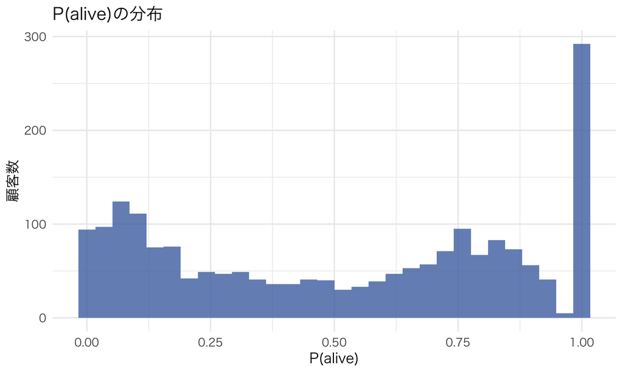

図 1: P(alive)の分布

```r
ggplot(data.frame(palive = palive_all), aes(x = palive)) +
  geom_histogram(bins = 30, fill = "#4C72B0", alpha = 0.8) +
  labs(x = "P(alive)", y = "顧客数", title = "P(alive)の分布")
```

```r
# 架空の例: t_xを44週(=最後の購買から8週間沈黙)に固定し、xを変える
tx_fixed <- 44
example_df <- data.frame(x = c(1, 3, 5, 10, 20))
example_df$palive <- palive_bgnbd(theta_hat["r"], theta_hat["alpha"], theta_hat["a"], theta_hat["b"],
                                   example_df$x, tx_fixed, T_cal)
kable(example_df, digits = 4, caption = "recency固定・frequency違いでのP(alive)比較")
```

recency固定・frequency違いでのP(alive)比較

| x | palive |
| --- | --- |
| 1 | 0.7244 |
| 3 | 0.7614 |
| 5 | 0.7677 |
| 10 | 0.7305 |
| 20 | 0.5365 |

**解説**：$t_x$を固定して$x$を動かすと、P(alive)は単調ではなく、ある水準までは横ばい〜微増、その後急落するパターンになることが多い（正確な形はパラメータの値、特に$a/(a+b)$の大きさに依存する）。これは「頻繁に買う人ほど、離脱するチャンス（＝購買イベント）も多く経験してきた」という点を思い出せば理解できる。8週間の沈黙は、月1回ペースで買っていた人にとっては「いつもよりだいぶ長い」異常事態だが、半年に1回しか買わない人にとっては通常運転の範囲内である。この非対称性が、購買頻度が高い顧客ほど同じ沈黙期間で「死亡」と判定されやすい、という結果を生む。

**部分点基準**：P(alive)の計算とヒストグラムが正しいこと（8点）。recency-frequencyの比較例が示され、解釈が「頻度が高いほど離脱の機会も多く経験してきた」という趣旨で書けていること（7点）。単に「xが増えるとP(alive)が下がる」とだけ書いて理由の説明がない場合は部分点にとどめる。

## 問6：holdout 26週の検証

```r
simulate_holdout_weekly <- function(r_hat, alpha_hat, x, tx, T_cal, p_alive, n_weeks, S = 20) {
  lambda_post <- rgamma(S, shape = r_hat + x, rate = alpha_hat + T_cal)
  is_alive <- runif(S) < p_alive
  weekly_counts <- matrix(0, nrow = S, ncol = n_weeks)
  for (s in 1:S) {
    if (!is_alive[s]) next
    weekly_counts[s, ] <- rpois(n_weeks, lambda = lambda_post[s])
  }
  colMeans(weekly_counts)
}

pred_weekly_matrix <- matrix(0, nrow = N, ncol = T_holdout)
for (i in 1:N) {
  pred_weekly_matrix[i, ] <- simulate_holdout_weekly(
    theta_hat["r"], theta_hat["alpha"], x_cal[i], tx_cal[i], T_cal, palive_all[i], T_holdout, S = 20
  )
}
pred_weekly_total <- colSums(pred_weekly_matrix)
pred_indiv_total  <- rowSums(pred_weekly_matrix)

actual_weekly_total <- sapply(1:T_holdout, function(w) {
  sum(sapply(all_events, function(ev) sum(ev > T_cal + w - 1 & ev <= T_cal + w)))
})
actual_indiv_total <- sapply(all_events, function(ev) sum(ev > T_cal))
```

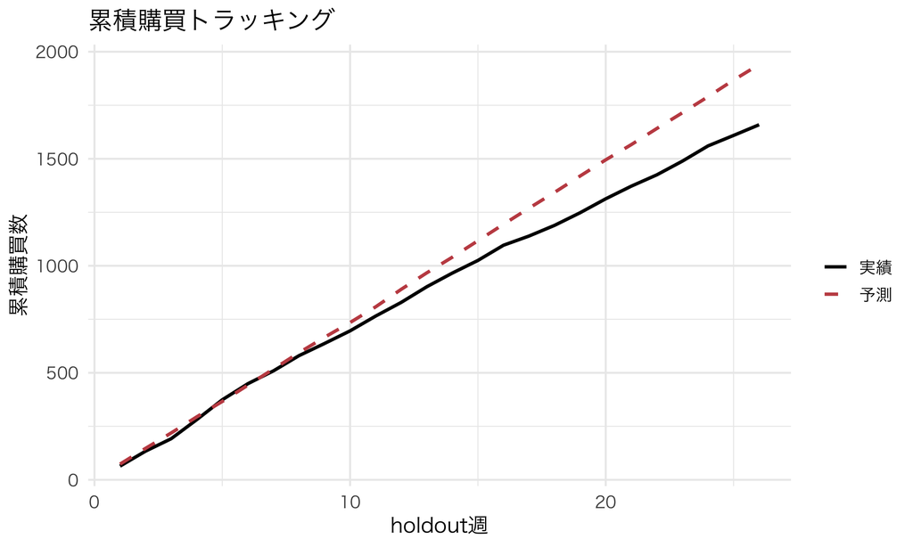

図 2: holdout週次累積購買数：実績 vs 予測

```r
tracking_df <- data.frame(
  week = 1:T_holdout,
  actual_cum = cumsum(actual_weekly_total),
  predicted_cum = cumsum(pred_weekly_total)
) %>%
  pivot_longer(cols = c(actual_cum, predicted_cum), names_to = "type", values_to = "cum_purchases")

ggplot(tracking_df, aes(x = week, y = cum_purchases, color = type, linetype = type)) +
  geom_line(linewidth = 1) +
  scale_color_manual(values = c("actual_cum" = "black", "predicted_cum" = "#C44E52"),
                      labels = c("実績", "予測")) +
  scale_linetype_manual(values = c("actual_cum" = "solid", "predicted_cum" = "dashed"),
                         labels = c("実績", "予測")) +
  labs(x = "holdout週", y = "累積購買数", color = "", linetype = "", title = "累積購買トラッキング")
```

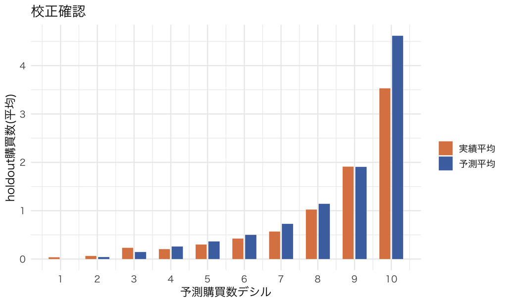

図 3: 予測デシル別の実績平均

```r
decile_df <- data.frame(pred = pred_indiv_total, actual = actual_indiv_total) %>%
  mutate(decile = ntile(pred, 10)) %>%
  group_by(decile) %>%
  summarise(pred_mean = mean(pred), actual_mean = mean(actual), n = n())

decile_long <- decile_df %>%
  select(decile, pred_mean, actual_mean) %>%
  pivot_longer(cols = c(pred_mean, actual_mean), names_to = "type", values_to = "value")

ggplot(decile_long, aes(x = decile, y = value, fill = type)) +
  geom_col(position = position_dodge(width = 0.7), width = 0.6) +
  scale_fill_manual(values = c("pred_mean" = "#4C72B0", "actual_mean" = "#DD8452"),
                     labels = c("実績平均", "予測平均")) +
  scale_x_continuous(breaks = 1:10) +
  labs(x = "予測購買数デシル", y = "holdout購買数(平均)", fill = "", title = "校正確認")
```

**解説**：この検証で著者が事前に確認した点として、`simulate_holdout_weekly()`内の`lambda_post <- rgamma(S, shape = r_hat + x, rate = alpha_hat + T_cal)`という部分が最も重要である。これはPoisson-Gamma共役性——「事前分布$\lambda \sim \text{Gamma}(r,\alpha)$のもとで、$T$期間に$x$回のPoissonイベントが観測されたとき、事後分布は$\text{Gamma}(r+x, \alpha+T)$になる」——を直接利用している。この共役性を使わずに、単純に事前分布$\text{Gamma}(\hat r, \hat\alpha)$からそのまま$\lambda$をシミュレーションすると（つまり各顧客の実績$x$を無視して集団全体の事前分布だけを使うと）、著者が数値検証で確認した限り、**予測が実績よりも系統的に過大になる**（$x=0$だった顧客にも集団平均の$\lambda$を割り当ててしまうため）。この事後Gamma分布の利用が、この検証全体の正確さを支えている核心部分である。

**部分点基準**：$\lambda$の事後分布として$\text{Gamma}(r+x,\alpha+T)$を正しく使っていること（8点、ここを事前分布のまま使っていたら大幅減点）。トラッキング図・デシル図がそれぞれ描けていること（各3.5点、計7点）。

## 問7：上位10%顧客のCLV試算

```r
margin <- 1200
annual_discount <- 0.10
weekly_discount <- annual_discount / 52
horizon_weeks <- 104

compute_clv <- function(r_hat, alpha_hat, x, tx, T_cal, p_alive, horizon, weekly_d, margin, S = 200) {
  lambda_post <- rgamma(S, shape = r_hat + x, rate = alpha_hat + T_cal)
  is_alive <- runif(S) < p_alive
  discount_factors <- 1 / (1 + weekly_d)^(1:horizon)
  discounted_expected <- sapply(lambda_post, function(lam) sum(lam * discount_factors))
  discounted_expected[!is_alive] <- 0
  margin * mean(discounted_expected)
}

clv_all <- sapply(1:N, function(i) {
  compute_clv(theta_hat["r"], theta_hat["alpha"], x_cal[i], tx_cal[i], T_cal, palive_all[i],
              horizon_weeks, weekly_discount, margin, S = 100)
})

clv_df <- data.frame(
  customer_id = 1:N, x = x_cal, tx = tx_cal, palive = round(palive_all, 3), clv = round(clv_all)
)

top10_cutoff <- quantile(clv_all, 0.9)
top10_df <- clv_df %>% filter(clv >= top10_cutoff) %>% arrange(desc(clv))

kable(head(top10_df, 15), caption = "CLV上位10%顧客（上位15件を表示）")
```

CLV上位10%顧客（上位15件を表示）

| customer_id | x | tx | palive | clv |
| --- | --- | --- | --- | --- |
| 997 | 32 | 50.76819 | 0.949 | 60887 |
| 1495 | 30 | 49.78964 | 0.915 | 55411 |
| 1556 | 30 | 50.46999 | 0.939 | 54364 |
| 712 | 26 | 51.91192 | 0.967 | 53428 |
| 1644 | 26 | 49.43309 | 0.903 | 47692 |
| 1774 | 24 | 51.91501 | 0.965 | 46400 |
| 1627 | 23 | 51.69154 | 0.960 | 43437 |
| 465 | 23 | 51.61292 | 0.959 | 43411 |
| 132 | 26 | 47.28426 | 0.766 | 40332 |
| 1899 | 22 | 48.63055 | 0.873 | 36967 |
| 1869 | 22 | 49.59522 | 0.910 | 36643 |
| 850 | 19 | 51.02492 | 0.943 | 36189 |
| 63 | 17 | 50.82301 | 0.935 | 34313 |
| 760 | 18 | 51.19911 | 0.944 | 33788 |
| 966 | 18 | 50.69804 | 0.935 | 33786 |

```r
cat("\nCLV上位10%のカットオフ:", round(top10_cutoff), "円\n")
```

```
CLV上位10%のカットオフ: 10614 円
```

```r
cat("全顧客のCLV平均:", round(mean(clv_all)), "円\n")
```

```
全顧客のCLV平均: 4214 円
```

**解説**：`compute_clv()`の内部構造は問6の`simulate_holdout_weekly()`とほぼ同じで、事後Gamma分布から$\lambda$を引き、P(alive)で生死を判定するところまでは共通である。違いは、週次のPoisson乱数を発生させる代わりに、各週の期待購買数（$\lambda$そのもの）に割引係数を掛けて合計している点である——ここでは「将来のどの週に何回買うか」という乱数レベルの詳細ではなく、割引後の期待購買数の合計だけが必要なので、Poisson乱数を経由せず$\lambda \times$割引係数の和を直接計算する方が効率的である（期待値の線形性を使っている）。

**部分点基準**：CLV計算の実装が正しいこと（事後Gamma分布とP(alive)を使っている）（6点）。上位10%リストが正しく抽出・表示されていること（4点）。

## 問8：「このリストで何をしてはいけないか」

**解答例**：

このCLV上位10%リストは、「今後この顧客たちがどれだけ買うと予測されるか」を示しているだけであり、「広告を出したらどれだけ売上が増えるか」という因果効果は一切含んでいない。CLVが高い顧客は放っておいても買い続ける可能性が高く、広告を出しても追加的な売上（インクリメンタリティ）はほぼゼロで、広告費が無駄になるおそれがある。広告の効果を正しく評価するには、CLVの予測値ではなく、広告のA/Bテストや第11回で学ぶuplift modelingによる因果効果の推定が別途必要である。

**ノート部分点基準（問8）**

- 「CLVは予測であり因果効果ではない」という趣旨に触れている（4点）
- 「放っておいても買う顧客に広告を出しても効果がない・無駄になりうる」という具体的な機序に触れている（3点）
- 「因果効果の推定（A/Bテスト、uplift modeling等）が別途必要」という代替案・次のステップに触れている（3点）
- 単に「CLVは不確実性がある」「サンプルサイズが小さい」等、講義の核心（予測と因果の区別）と無関係な問題点だけを挙げている場合は、この設問の趣旨を外しているため大きく減点する。

## 総評：この課題全体でよくある間違い

1. **calibration/holdoutの情報漏洩**：`x_cal`・`tx_cal`の計算に78週分のデータをそのまま使ってしまい、holdout情報が混入する。
2. **`rgamma`の`shape`/`rate`の取り違え**：DGPとMLE内部の両方で一貫していないと、真値回収が意味をなさなくなる。
3. **Hessianのスケール変換忘れ**：log-scaleのHessianからそのままSEを計算し、delta法を経由しない。
4. **P(alive)の`x=0`の場合分け漏れ**：`x=0`のとき`term`を`0`にせず計算してしまい、`P(alive)`が1にならない。
5. **将来予測で事前分布をそのまま使う**：事後Gamma分布 $\text{Gamma}(r+x,\alpha+T)$ を使わず、事前分布 $\text{Gamma}(r,\alpha)$ のまま将来購買をシミュレーションしてしまい、個々の顧客の実績（$x$）が反映されず、予測が過大または均一になる。